# Perch behavior coordinated?

Annemarie van der Marel

08/07/2020

Code for manuscript titled

Synchronizing vigilance or taking turns as sentinels? The importance of testing assumptions

by

Annemarie van der Marel, Jane M. Waterman, Marta López-Darias

perch behavior general description do all inidviduals perform perch behavior? prop group members perched per scan

perch behavior coordination perch behavior from elevated positions? (prediction 1) coordination of perch bouts? (predictions 2 and 3)

perch behavior and social conditions analyses age (prediction 4) kinship (prediction 5) parental behavior (prediction 6)

perch behavior and survival analyses increased survival (prediction 7) decreased survival (prediction 8) perch behavior as induced viggilance? (prediction 9)

# Load libraries

```r
library(dplyr)
library(tidyverse)
library(ggplot2)
library(tidyr)
library(quantreg)
library(lqmm)
library(lme4)
library(glmmADMB)
#install.packages("R2admb")
#install.packages("glmmADMB",
#    repos=c("http://glmmadmb.r-forge.r-project.org/repos",
#            getOption("repos")),
#    type="source")
library(lmtest)
library(betareg)
library(DHARMa)
library(beanplot)
```

# import data

We used 10 min scan samples and all occurrence sampling of perch bouts throughout each behavioral observation period in addition to performing 10 min focal follows

```r
## All scans from March till July 2014 to 2016
# exlcuded estrus days, all occurrences and unknown ID's, and individuals observed <5 observation periods (dop) and <5 scans (dos)
scandata<-read.csv("FilteredScanPerchData.csv") # was named 'df' in R code script

## scan and all-occurrence data from our Prim8 input
#June and July 2015, February till June 2016 excluding all subset criteria
scandata_prim8<-read.csv("FilteredScanPerchData_Prim8.csv", sep = ",")

## focal follow data
ff<- read.csv("Aget_focal follows.csv", sep=",") %>%
  dplyr::select(-X)
```

#### Perch behavior general description

Do all inidviduals perform perch behavior?

```r
# used scandata filterd for ID's observed in at least 5 scans in 5 observation periods
nIDs<-distinct(scandata, ID)  # 139 ID's observed
nperched<-filter(scandata, Behaviour.1=="perch") %>%
  distinct(ID)  # 138 perched
length(nperched$ID)/length(nIDs$ID)*100 # With filter: 99.3% individuals perch
```

```
## [1] 99.28058
```

Proportion group members perched per scan

```r
propperch<-group_by(scandata, dop, dos)
p1 <- filter(propperch, Behaviour.1 =="perch") %>%
  summarise(nperch = n())
p2<- summarise(propperch, groupsize = n_distinct(ID))

# prop group members on group size
percperch<- p2 %>% left_join(p1, by=c("dop","dos"))
percperch[is.na(percperch)] <- 0
percperch<-  mutate(percperch, perched= nperch/groupsize) %>%
  ungroup()

# number of scans
n_distinct(propperch$dos)
```

```
## [1] 3134
```

```r
3134/6 # excluding iDs <5 dop and dos seen
```

```
## [1] 522.3333
```

```r
3174/6 # all individuals included
```

```
## [1] 529
```

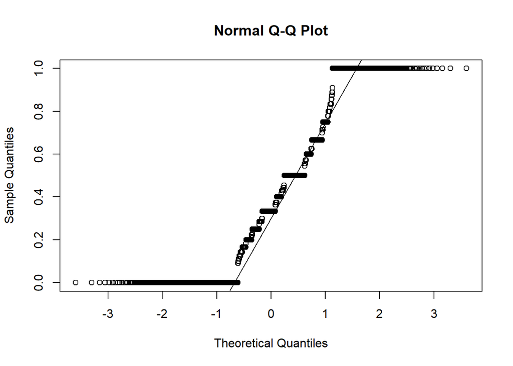

```r
# average number of individuals perched per group
perchperscan<-summarise(percperch, mean=mean(perched), sd=sd(perched),
                        n=n(), se=sd/sqrt(n),
                        min=min(perched),max=max(perched))

# what distribution does proportion group members follow?
qqnorm(percperch$perched)
qqline(percperch$perched)
```

```r
shapiro.test(percperch$perched)
```

```
##
##  Shapiro-Wilk normality test
##
## data:  percperch$perched
## W = 0.89292, p-value < 2.2e-16
```

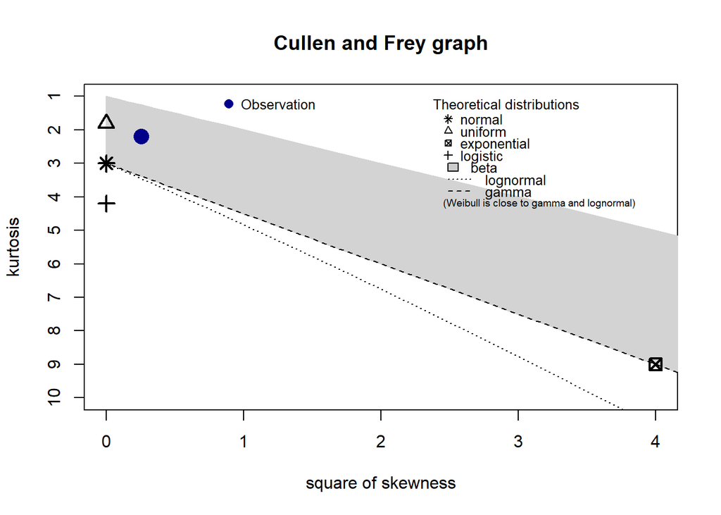

```
## summary statistics
## ------
## min:  0   max:  1
## median:  0.3333333
## mean:  0.3839542
## estimated sd:  0.3309292
## estimated skewness:  0.5035218
## estimated kurtosis:  2.193704
```

```r
library(fitdistrplus)
descdist(percperch$perched, discrete = FALSE) # beta distribution
```

```r
library(betareg)
percperch$perched[percperch$perched==0.00]<-0.001
percperch$perched[percperch$perched==1.00]<-0.999
model<-betareg(perched ~ groupsize , data = percperch)
null<-betareg(perched ~ 1 , data = percperch)
summary(model)
```

```
##
## Call:
## betareg(formula = perched ~ groupsize, data = percperch)
##
## Standardized weighted residuals 2:
##     Min      1Q  Median      3Q     Max
## -1.2805 -1.2617  0.1121  0.3531  1.7985
##
## Coefficients (mean model with logit link):
##              Estimate Std. Error z value Pr(>|z|)
## (Intercept) -0.367918   0.046021  -7.995  1.3e-15 ***
## groupsize    0.001877   0.009680   0.194    0.846
##
## Phi coefficients (precision model with identity link):
##       Estimate Std. Error z value Pr(>|z|)
## (phi)  0.69612    0.01362    51.1   <2e-16 ***
## ---
## Signif. codes:  0 '***' 0.001 '**' 0.01 '*' 0.05 '.' 0.1 ' ' 1
##
## Type of estimator: ML (maximum likelihood)
## Log-likelihood:  2634 on 3 Df
## Pseudo R-squared: 1.324e-05
## Number of iterations: 12 (BFGS) + 1 (Fisher scoring)
```

```r
library(lmtest)
lrtest(model, null)
```

```
## Likelihood ratio test
##
## Model 1: perched ~ groupsize
## Model 2: perched ~ 1
##   #Df LogLik Df  Chisq Pr(>Chisq)
## 1   3 2633.6
## 2   2 2633.5 -1 0.0373     0.8468
```

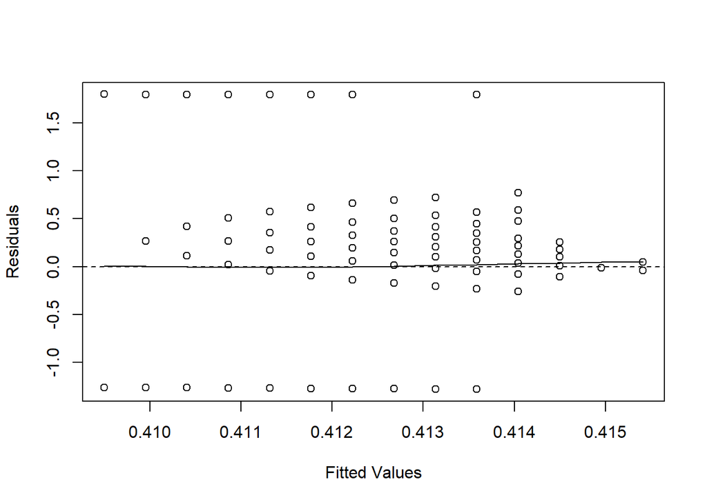

```r
# model validation
plot(fitted(model), residuals(model), xlab = "Fitted Values", ylab = "Residuals")
abline(h = 0, lty = 2) #create a dashed horizontal line representing zero
lines(smooth.spline(fitted(model), residuals(model))) # line should fall on zero line
```

The overall distribution of individuals perched

```r
## watch each other's back? ----
collperch<- mutate(percperch, bin = "" )
collperch$bin[collperch$nperch==1]<-1
collperch$bin[collperch$nperch>1]<-">1"
collperch$bin[collperch$nperch==0]<-0
collperch$bin<-factor(collperch$bin, levels=c(0,1,">1"))
collperch1<-filter(collperch, bin!="0" )

distr.perched<- group_by(collperch, bin) %>%
  summarise(n=n()) %>%
  mutate(perc =n/sum(n)*100)

sum(distr.perched$n) # total 3134 scans
```

```
## [1] 3134
```

```r
propperched<- c(0.2715, 0.3191, 0.4094)
chisq.test(propperched, p = c(1/3, 1/3, 1/3))
```

```
##
##  Chi-squared test for given probabilities
##
## data:  propperched
## X-squared = 0.029436, df = 2, p-value = 0.9854
```

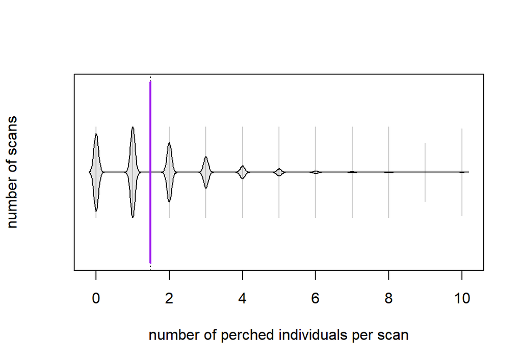

```r
#set plot color by plot element
bean.alpha <- 0.4
beaninlines <- alpha("black", 0.2)
beanoutlines<- alpha("black", 0.2)
beanavgline <- "purple"
beanborder <- alpha("black", 0.6)

beanplot(collperch$nperch, las=1, ylab= "number of scans",
         xlab =  "number of perched individuals per scan",
         col = list(c(alpha("grey", bean.alpha), beaninlines, beaninlines, "purple")),
         maxstripline = 0.5, maxwidth = 0.5, horizontal = T)
```

```r
# save plot
dev.print(pdf, file="fig1.pdf")
```

#### Perch behavior coordination

# Prediction 1: Perched from elevated positions

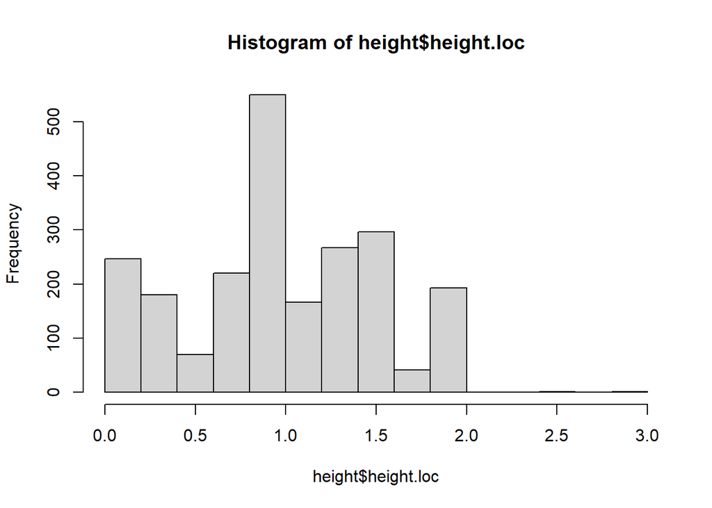

```r
# combine heights any other behavior or when perched
o <- subset(scandata, height.loc!="na"& Behaviour.1!="perch")%>%
  mutate(behavior="all") # any other behavior, excluding perch
p<- subset(scandata, height.loc!="na" & Behaviour.1=="perch" & height.loc>0.3) %>%
  mutate(behavior="perch") # perch
height<-bind_rows(o,p) %>%
  filter(height.loc<8)

hist(height$height.loc)
```

```r
shapiro.test(height$height.loc)
```

```
##
##  Shapiro-Wilk normality test
##
## data:  height$height.loc
## W = 0.95966, p-value < 2.2e-16
```

```r
wilcox.test(height$height.loc ~ factor(height$behavior))
```

```
##
##  Wilcoxon rank sum test with continuity correction
##
## data:  height$height.loc by factor(height$behavior)
## W = 391100, p-value < 2.2e-16
## alternative hypothesis: true location shift is not equal to 0
```

```r
#Mann-Whitney Z test
N = 2230
MWa <- wilcox.test(height$height.loc~ factor(height$behavior), exact=FALSE)
MWa
```

```
##
##  Wilcoxon rank sum test with continuity correction
##
## data:  height$height.loc by factor(height$behavior)
## W = 391100, p-value < 2.2e-16
## alternative hypothesis: true location shift is not equal to 0
```

```r
Za = qnorm(MWa$p.value/2)
Za
```

```
## [1] -13.49856
```

```r
# A common effect size statistic for the Mann–Whitney test is r,
# which is the Z value from the test divided by the total number of
# observations.  As written here, r varies from 0 to close to 1.
# In some formulations, it varies from –1 to 1.
ra = abs(Za)/sqrt(N)
names(ra) = "ra"
ra
```

```
##        ra
## 0.2858478
```

```r
## descriptives
sumheight<-group_by(height, behavior) %>%
  summarise(mean=mean(height.loc), sd=sd(height.loc), n=n(),
            se=sd/n)
sumheight
```

```
## # A tibble: 2 x 5
##   behavior  mean    sd     n       se
##   <chr>    <dbl> <dbl> <int>    <dbl>
## 1 all      0.864 0.589  1365 0.000432
## 2 perch    1.21  0.416   865 0.000481
```

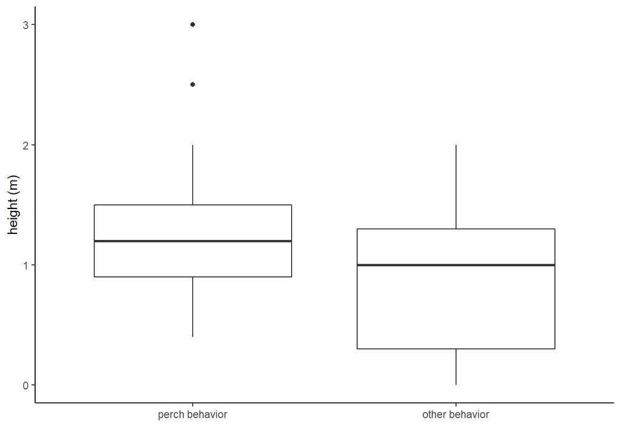

```r
## boxplot
cat<- factor(height$behavior, levels = c("perch","all"),
             labels= c("perch behavior", "other behavior"))
Fig2<-ggplot(height, aes(x = cat, y=height.loc)) +
  geom_boxplot() +
  theme_classic() +
  labs(x="", y="height (m)")
Fig2
```

```r
ggsave("fig2.pdf", width = 84, height = 84, units = "mm")
```

# Predictions 2 and 3: Coordination of perch behavior

ready data

```r
head(scandata_prim8)
```

```
##   X Orderkey Observer Year Julian.date juveniles   dop      dos Site All  ID
## 1 1    19866       AM 2015         492   present 492_1 492_1_82    1      17
## 2 2    19867       AM 2015         492   present 492_1 492_1_82    1      26
## 3 3    19868       AM 2015         492   present 492_1 492_1_82    1      18
## 4 4    19869       AM 2015         492   present 492_1 492_1_82    1     131
## 5 5    19870       AM 2015         492   present 492_1 492_1_82    1     151
## 6 6    19871       AM 2015         492   present 492_1 492_1_82    1     131
##   group Sex Age Posture         Behaviour.1          location height dc
## 1    1m   1   1      s4               perch  1_sand dam_25_NW    1.0  0
## 2   1fb   2   1      s4               perch    1_upper rw_5_n    2.0  0
## 3    1m   1   1                    sit (s4)   1_main burrow__    0.0  0
## 4   1ft   2   3         carry nest material 1_main burrow_5_S     NA NA
## 5   1ft   2   3      s4               perch   1_main burrow__    0.5  0
## 6   1ft   2   3                  chase <10m   1_main burrow__    0.5 NA
##       Time duration
## 1 10:32:05     1166
## 2 10:33:16      736
## 3 10:34:07        0
## 4 10:34:44        0
## 5 10:36:02      182
## 6 10:37:07        0
```

```r
str(scandata_prim8)
```

```
## 'data.frame':    4436 obs. of  21 variables:
##  $ X          : int  1 2 3 4 5 6 7 8 9 10 ...
##  $ Orderkey   : chr  "19866" "19867" "19868" "19869" ...
##  $ Observer   : chr  "AM" "AM" "AM" "AM" ...
##  $ Year       : int  2015 2015 2015 2015 2015 2015 2015 2015 2015 2015 ...
##  $ Julian.date: int  492 492 492 492 492 492 492 492 492 492 ...
##  $ juveniles  : chr  "present" "present" "present" "present" ...
##  $ dop        : chr  "492_1" "492_1" "492_1" "492_1" ...
##  $ dos        : chr  "492_1_82" "492_1_82" "492_1_82" "492_1_82" ...
##  $ Site       : int  1 1 1 1 1 1 1 1 1 1 ...
##  $ All        : chr  "" "" "" "" ...
##  $ ID         : int  17 26 18 131 151 131 17 26 131 18 ...
##  $ group      : chr  "1m" "1fb" "1m" "1ft" ...
##  $ Sex        : int  1 2 1 2 2 2 1 2 2 1 ...
##  $ Age        : int  1 1 1 3 3 3 1 1 3 1 ...
##  $ Posture    : chr  "s4" "s4" "" "" ...
##  $ Behaviour.1: chr  "perch" "perch" "sit (s4)" "carry nest material" ...
##  $ location   : chr  "1_sand dam_25_NW" "1_upper rw_5_n" "1_main burrow__" "1_main burrow_5_S" ...
##  $ height     : num  1 2 0 NA 0.5 0.5 NA NA 1 NA ...
##  $ dc         : num  0 0 0 NA 0 NA NA NA 0 NA ...
##  $ Time       : chr  "10:32:05" "10:33:16" "10:34:07" "10:34:44" ...
##  $ duration   : int  1166 736 0 0 182 0 234 579 175 438 ...
```

```r
# only select individuals that were observed in 5 scans over at least 5 observation periods
scandata_prim8_filtered <-  group_by(scandata_prim8, ID) %>%
  mutate(total.dop=n_distinct(dop), total.scan=n_distinct(dos)) %>%
  filter(total.dop>=5)

al<-scandata_prim8_filtered # all individuals
a<- filter(scandata_prim8_filtered , Age!="4") # only adults
fem <- filter(scandata_prim8_filtered , Sex!="1"& Age!="4") # only adult females
```

Individual –> at least 1 perched

```r
# Observed proportion at least 1 perched ----------------------------

# all
dop1 <-  group_by(al, dop) %>% dplyr::select(Orderkey,dos,dop,ID,group,Behaviour.1,duration)
op <-  group_by(al, dop, ID) %>%
  dplyr::select(Orderkey,dos,dop,All,ID,group,'Behaviour.1',duration)
obs <-  summarise(op,scans.ID = n_distinct(dos))
obs1<- group_by(obs, dop) %>%
  summarise(total.scans = sum(scans.ID),
            grp.size = n_distinct(ID)) %>%
  mutate(time.scans= total.scans*600)  # scans each ID /dop observed
dop3 <- filter(dop1, Behaviour.1 =="perch", duration > 30) %>%
  summarise(time.perch = sum(duration))
dop <- obs1 %>% left_join(dop3, by = "dop") %>%
  mutate(Pobs.all= time.perch/time.scans) %>% drop_na()
duration<-dplyr::select(dop, dop, Pobs.all)

# adults
dop1 <-  group_by(a, dop) %>%
  dplyr::select(Orderkey,dos,dop,ID,group,Behaviour.1,duration)
op <-  group_by(a, dop, ID) %>%
  dplyr::select(Orderkey,dos,dop,All,ID,group,'Behaviour.1',duration)
obs <-  summarise(op,scans.ID = n_distinct(dos))
obs1<- group_by(obs, dop) %>%
  summarise(total.scans = sum(scans.ID),
            grp.size = n_distinct(ID)) %>%
  mutate(time.scans= total.scans*600)  # scans each ID /dop observed
dop3 <- filter(dop1, Behaviour.1 =="perch", duration > 30) %>%
  summarise(time.perch = sum(duration))
dop <- obs1 %>% left_join(dop3, by = "dop") %>%
  mutate(Pobs.adults= time.perch/time.scans) %>% drop_na() %>%
  dplyr::select(dop, Pobs.adults)
duration<-duration %>% left_join(dop,by="dop")

# females
dop1 <-  group_by(fem, dop) %>%
  dplyr::select(Orderkey,dos,dop,ID,group,Behaviour.1,duration)
op <-  group_by(fem, dop, ID) %>%
  dplyr::select(Orderkey,dos,dop,All,ID,group,'Behaviour.1',duration)
obs <-  summarise(op,scans.ID = n_distinct(dos))
obs1<- group_by(obs, dop) %>%
  summarise(total.scans = sum(scans.ID),
            grp.size = n_distinct(ID)) %>%
  mutate(time.scans= total.scans*600)  # scans each ID /dop observed
dop3 <- filter(dop1, Behaviour.1 =="perch", duration > 30) %>%
  summarise(time.perch = sum(duration))
dop <- obs1 %>% left_join(dop3, by = "dop") %>%
  mutate(Pobs.females= time.perch/time.scans) %>%
  dplyr::select(dop, Pobs.females)
duration<-duration %>% left_join(dop,by="dop")


# Expected proportion at least 1 perched ----------------------------

# all
op <-  group_by(al, dop, ID) %>%
  dplyr::select(Orderkey,dos,dop,All,ID,group,'Behaviour.1',duration)
op1 <-  summarise(op,scans.obs = n_distinct(dos))  %>%
  mutate(time.obs = scans.obs*600)
op2 <- op %>% filter(Behaviour.1== "perch", duration > 30) %>%
  summarise(time.perch = sum(duration))
prop = merge(op1, op2,all.x = T)
prop$time.perch[is.na(prop$time.perch)]=0
Pexp.dur <- mutate(prop, exp.dur = time.perch/time.obs)
#write.csv(Pexp.dur, file="expected.duration.all_draft7.csv")

# multiplied expected proportion per group in Excel
exp =read.csv(file="expected.duration.all_draft7.csv", sep = ";")
product <- exp  %>% group_by(dop) %>% dplyr::select(dop, expected) %>%
  summarise(exp.all=last(expected)) %>% dplyr::select(dop, exp.all) %>%
  mutate(one=1, Pexp.all=one-exp.all) %>% dplyr::select(dop, Pexp.all)

duration<-duration %>% left_join(product, by="dop")

# adults
op <-  group_by(a, dop, ID) %>%
  dplyr::select(Orderkey,dos,dop,All,ID,group,'Behaviour.1',duration)
op1 <-  summarise(op,scans.obs = n_distinct(dos))  %>%
  mutate(time.obs = scans.obs*600)
op2 <- op %>% filter(Behaviour.1== "perch", duration > 30) %>%
  summarise(time.perch = sum(duration))
prop = merge(op1, op2,all.x = T)
prop$time.perch[is.na(prop$time.perch)]=0
Pexp.dur <- mutate(prop, exp.dur = time.perch/time.obs)
#write.csv(Pexp.dur, file="expected.duration.adults_draft7.csv")
exp = read.csv(file="expected.duration.adults_draft7.csv", sep = ";")
product <- exp  %>% group_by(dop) %>%
  dplyr::select(dop, product) %>%
  summarise(exp.adults=last(product)) %>%
  dplyr::select(dop, exp.adults)%>%
  mutate(one=1, Pexp.adults=one-exp.adults) %>%
  dplyr::select(dop, Pexp.adults)
duration<-duration %>% left_join(product, by="dop")


# females
op <-  group_by(fem, dop, ID) %>%
  dplyr::select(Orderkey,dos,dop,All,ID,group,'Behaviour.1',duration)
op1 <-  summarise(op,scans.obs = n_distinct(dos))  %>%
  mutate(time.obs = scans.obs*600)
op2 <- op %>% filter(Behaviour.1== "perch", duration > 30) %>%
  summarise(time.perch = sum(duration))
prop = merge(op1, op2,all.x = T)
prop$time.perch[is.na(prop$time.perch)]=0
Pexp.dur <- mutate(prop, exp.dur = time.perch/time.obs)
#write.csv(Pexp.dur, file="expected.duration.females_draft7.csv")
exp =read.csv(file="expected.duration.females_draft7.csv", sep = ";")
product <- exp  %>% group_by(dop) %>% dplyr::select(dop, product) %>%
  summarise(exp.females=last(product)) %>%
  dplyr::select(dop, exp.females)%>%
  mutate(one=1, Pexp.females=one-exp.females) %>%
  dplyr::select(dop, Pexp.females)

duration<-duration %>% left_join(product, by="dop")


# combine -------------
result<-mutate(duration, diff.all=Pobs.all-Pexp.all,
               diff.adults=Pobs.adults-Pexp.adults,
               diff.females=Pobs.females-Pexp.females)

# Wilcoxon signed-rank test -----------------------------------------

## all individuals / duraiton
wilcox.test(result$Pobs.all,result$Pexp.all, paired = T)
```

```
##
##  Wilcoxon signed rank test with continuity correction
##
## data:  result$Pobs.all and result$Pexp.all
## V = 496, p-value < 2.2e-16
## alternative hypothesis: true location shift is not equal to 0
```

```r
# observed
mean(result$Pobs.all)
```

```
## [1] 0.1895288
```

```r
sd(result$Pobs.all)/sqrt(length(result$Pobs.all))
```

```
## [1] 0.01919171
```

```r
#expected
mean(result$Pexp.all,na.rm=TRUE)
```

```
## [1] 0.5448434
```

```r
sd(result$Pexp.all, na.rm = TRUE)/sqrt(length(result$Pexp.all))
```

```
## [1] 0.03163852
```

```r
# difference
mean(result$diff.all,na.rm=TRUE)
```

```
## [1] -0.3553146
```

```r
sd(result$diff.all,na.rm=TRUE)/sqrt(length(result$diff.all))
```

```
## [1] 0.02866231
```

```r
# sample size
al<-subset(duration, Pexp.all!="NA")
length(result$Pobs.all)
```

```
## [1] 125
```

```r
rm(al)

## adults / duration
wilcox.test(result$Pobs.adults,result$Pexp.adults, paired = T,na.action="omit" )
```

```
##
##  Wilcoxon signed rank test with continuity correction
##
## data:  result$Pobs.adults and result$Pexp.adults
## V = 158, p-value < 2.2e-16
## alternative hypothesis: true location shift is not equal to 0
```

```r
# observed
mean(result$Pobs.adults,na.rm = TRUE)
```

```
## [1] 0.1978176
```

```r
sd(result$Pobs.adults,na.rm = TRUE)/sqrt(length(result$Pobs.adults))
```

```
## [1] 0.01970991
```

```r
# expected
mean(result$Pexp.adults,na.rm=TRUE)
```

```
## [1] 0.5192754
```

```r
sd(result$Pexp.adults, na.rm = TRUE)/sqrt(length(result$Pexp.adults))
```

```
## [1] 0.02779254
```

```r
# difference
mean(result$diff.adults,na.rm=TRUE)
```

```
## [1] -0.3299705
```

```r
sd(result$diff.adults,na.rm=TRUE)/sqrt(length(result$diff.adults))
```

```
## [1] 0.0265309
```

```r
ad<-subset(duration, Pobs.adults!="NA")
length(ad$Pobs.adults)
```

```
## [1] 122
```

```r
rm(ad)

## adult females / duration
wilcox.test(result$Pobs.females,result$Pexp.females, paired = T,na.action="omit" )
```

```
##
##  Wilcoxon signed rank test with continuity correction
##
## data:  result$Pobs.females and result$Pexp.females
## V = 40, p-value < 2.2e-16
## alternative hypothesis: true location shift is not equal to 0
```

```r
# observed
mean(result$Pobs.females, na.rm = TRUE)
```

```
## [1] 0.1933866
```

```r
sd(result$Pobs.females, na.rm = TRUE)/sqrt(length(result$Pobs.females))
```

```
## [1] 0.01470506
```

```r
# expected
mean(result$Pexp.females,na.rm=TRUE)
```

```
## [1] 0.4445782
```

```r
sd(result$Pexp.females, na.rm = TRUE)/sqrt(length(result$Pexp.females))
```

```
## [1] 0.02988694
```

```r
# difference
mean(result$diff.females,na.rm=TRUE)
```

```
## [1] -0.2885861
```

```r
sd(result$diff.females,na.rm=TRUE)/sqrt(length(result$diff.females))
```

```
## [1] 0.02182535
```

```r
fem<-subset(duration, Pobs.females!="NA")
length(fem$Pexp.females)
```

```
## [1] 107
```

```r
rm(fem)

# clean up
rm(obs, obs1, dop1, dop3,a,dop,exp,op,op2,p,Pexp.dur,product,
   prop, op1,f,dur)
```

#### perch behavior and social conditions analyses

# Age (prediction 4)

Do different age classes differ in the time they spent foraging, low-quality vigilance and perching?

```r
str(scandata)
```

```
## 'data.frame':    12956 obs. of  22 variables:
##  $ X          : int  1 2 3 4 5 6 7 8 9 10 ...
##  $ Orderkey   : int  1 2 3 4 5 6 7 8 9 10 ...
##  $ Year       : int  2014 2014 2014 2014 2014 2014 2014 2014 2014 2014 ...
##  $ Julian.date: int  29 29 29 29 29 29 29 29 29 29 ...
##  $ juveniles  : chr  "absent" "absent" "absent" "absent" ...
##  $ dos        : chr  "29_1_1" "29_1_1" "29_1_1" "29_1_2" ...
##  $ dop        : chr  "29_1" "29_1" "29_1" "29_1" ...
##  $ Scan       : int  1 1 1 2 2 2 2 2 3 3 ...
##  $ Site       : int  1 1 1 1 1 1 1 1 1 1 ...
##  $ All        : logi  NA NA NA NA NA NA ...
##  $ ID         : int  22 23 29 22 23 29 35 31 23 29 ...
##  $ group      : chr  "1fb" "1fb" "1fb" "1fb" ...
##  $ Sex        : int  2 2 2 2 2 2 2 1 2 2 ...
##  $ Age        : int  1 3 1 1 3 1 1 1 3 1 ...
##  $ Posture    : chr  "" "S4" "S4" "" ...
##  $ Behaviour.1: chr  "out burrow" "perch" "perch" "stretch" ...
##  $ Behaviour.2: chr  "" "" "" "" ...
##  $ duration   : int  NA NA NA NA NA NA NA NA NA NA ...
##  $ Time       : chr  "11:12:38" "11:18:35" "11:19:42" "11:25:15" ...
##  $ height.loc : num  1 1 NA 0.65 1 1 NA NA 1 NA ...
##  $ total.dop  : int  44 56 44 44 56 44 15 48 56 44 ...
##  $ totaldos   : int  227 325 222 227 325 222 65 256 325 222 ...
```

```r
IDage<-dplyr::select(scandata, ID, Age) %>% group_by(ID) %>%
  summarise(Age= first(Age)) %>% filter(Age!=3)
IDage$ID<-as.integer(IDage$ID)

# foraging
f0<-  group_by(scandata, dop, ID) %>%
  dplyr::select(Orderkey,dos,dop,All,ID,group,Behaviour.1,Behaviour.2,duration)
f1 <- summarise(f0, scans.obs = n_distinct(dos))
f2 <-filter(f0,Behaviour.1== "feed" | Behaviour.2=="feed") %>%
  summarise(scans.feed= n_distinct(dos))
f3 = merge(f1,f2,all.x = T)
f3$scans.feed[is.na(f3$scans.feed)]=0
f3$scans.obs[is.na(f3$scans.obs)]=0
IDfeed <- mutate(f3, IDfeed= scans.feed/scans.obs) %>% drop_na(ID)

IDfeedage<- group_by(IDfeed, ID) %>%
  summarise(avgIDfeed=mean(IDfeed))
IDfeedage <- merge(IDfeedage,IDage,all.x = T) %>%
  drop_na()

kruskal.test(IDfeedage$avgIDfeed~ IDfeedage$Age)
```

```
##
##  Kruskal-Wallis rank sum test
##
## data:  IDfeedage$avgIDfeed by IDfeedage$Age
## Kruskal-Wallis chi-squared = 8.1956, df = 2, p-value = 0.01661
```

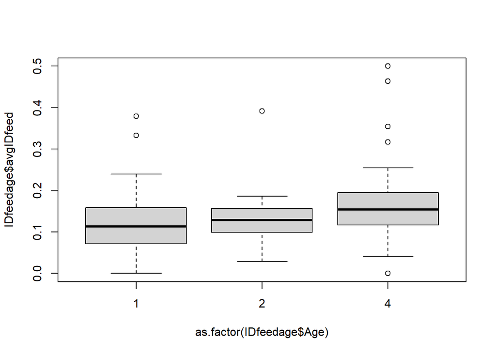

```r
plot(IDfeedage$avgIDfeed~ as.factor(IDfeedage$Age))
```

```r
pairwise.wilcox.test(IDfeedage$avgIDfeed, IDfeedage$Age, p.adjust.method = "holm")
```

```
##
##  Pairwise comparisons using Wilcoxon rank sum test with continuity correction
##
## data:  IDfeedage$avgIDfeed and IDfeedage$Age
##
##   1     2
## 2 0.403 -
## 4 0.017 0.224
##
## P value adjustment method: holm
```

```r
sumfeed<-group_by(IDfeedage, Age) %>%
  summarise( mean=mean(avgIDfeed), SD=sd(avgIDfeed), n=length(avgIDfeed))

age.feed<-rename(IDfeedage, prop=avgIDfeed, age=Age) %>%
  mutate(behavior="feeding")

# low-quality vigilance
v <-  group_by(scandata, dop, ID) %>%
  dplyr::select(Orderkey,dos,dop,All,ID,group,Behaviour.1,Behaviour.2,duration)
v1 <- summarise(v, scans.obs = n_distinct(dos))
v2 <-filter(v,Behaviour.1== "vigilant" | Behaviour.2=="vigilant") %>%
  summarise(scans.vig= n_distinct(dos))
v3 = merge(v1,v2,all.x = T)
v3$scans.vig[is.na(v3$scans.vig)]=0
v3$scans.obs[is.na(v3$scans.obs)]=0
IDvig<- mutate(v3, ID.vig= scans.vig/scans.obs) %>% drop_na(ID)

IDvigAge<- group_by(IDvig, ID) %>%
  summarise(avgIDvig=mean(ID.vig))
IDvigAge<- left_join(IDvigAge, IDage,by="ID") %>%
  drop_na()
age.vig<-rename(IDvigAge, prop=avgIDvig, age=Age) %>%
  mutate(behavior="low-quality vigilant")

kruskal.test(IDvigAge$avgIDvig~ IDvigAge$Age)
```

```
##
##  Kruskal-Wallis rank sum test
##
## data:  IDvigAge$avgIDvig by IDvigAge$Age
## Kruskal-Wallis chi-squared = 8.8782, df = 2, p-value = 0.01181
```

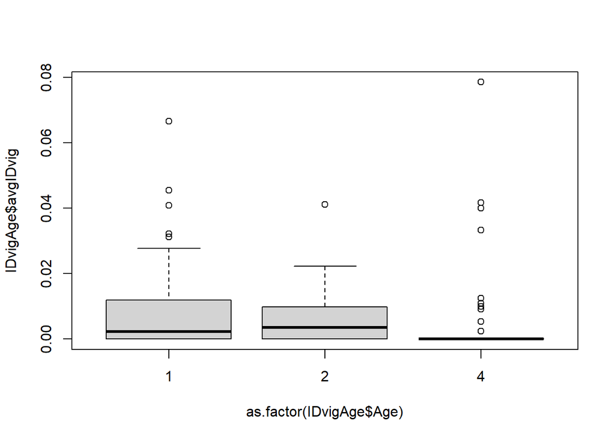

```r
plot(IDvigAge$avgIDvig~ as.factor(IDvigAge$Age))
```

```r
pairwise.wilcox.test(IDvigAge$avgIDvig,IDvigAge$Age)
```

```
##
##  Pairwise comparisons using Wilcoxon rank sum test with continuity correction
##
## data:  IDvigAge$avgIDvig and IDvigAge$Age
##
##   1     2
## 2 0.588 -
## 4 0.024 0.015
##
## P value adjustment method: holm
```

```r
sumvig<-group_by(IDvigAge, Age) %>%
  summarise( mean=mean(avgIDvig), SD=sd(avgIDvig), n=length(avgIDvig))

# perch
p <-  group_by(scandata, dop, ID) %>%
  dplyr::select(Orderkey,dos,dop,All,ID,group,Behaviour.1,Behaviour.2,duration)
p1 <- summarise(p, scans.obs = n_distinct(dos))
p2 <-filter(p,Behaviour.1== "perch" | Behaviour.2=="perch") %>%
  summarise(scans.perch= n_distinct(dos))
p3 = merge(p1,p2,all.x = T)
p3$scans.perch[is.na(p3$scans.perch)]=0
p3$scans.obs[is.na(p3$scans.obs)]=0
IDperch <- mutate(p3, ID.perch= scans.perch/scans.obs) %>% drop_na(ID)

IDperchAge<- group_by(IDperch, ID) %>%
  summarise(avgIDperch=mean(ID.perch))
IDperchAge<- left_join(IDperchAge, IDage, by="ID") %>%
  drop_na()

age.perch<- rename(IDperchAge, prop=avgIDperch, age=Age) %>%
  mutate(behavior="perching")

kruskal.test(IDperchAge$avgIDperch~ IDperchAge$Age)
```

```
##
##  Kruskal-Wallis rank sum test
##
## data:  IDperchAge$avgIDperch by IDperchAge$Age
## Kruskal-Wallis chi-squared = 11.65, df = 2, p-value = 0.002954
```

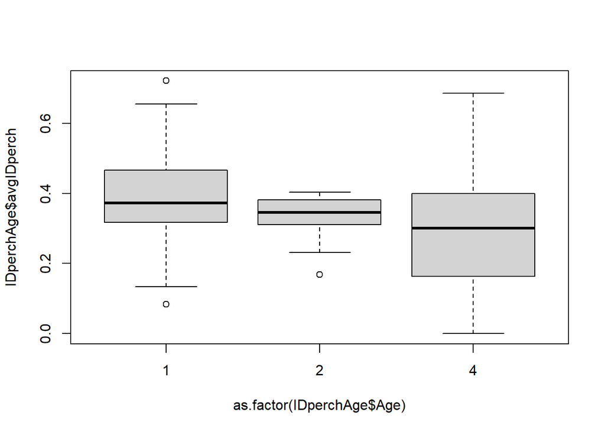

```r
plot(IDperchAge$avgIDperch~ as.factor(IDperchAge$Age))
```

```r
pairwise.wilcox.test(IDperchAge$avgIDperch,IDperchAge$Age)
```

```
##
##  Pairwise comparisons using Wilcoxon rank sum test with continuity correction
##
## data:  IDperchAge$avgIDperch and IDperchAge$Age
##
##   1      2
## 2 0.0963 -
## 4 0.0046 0.2254
##
## P value adjustment method: holm
```

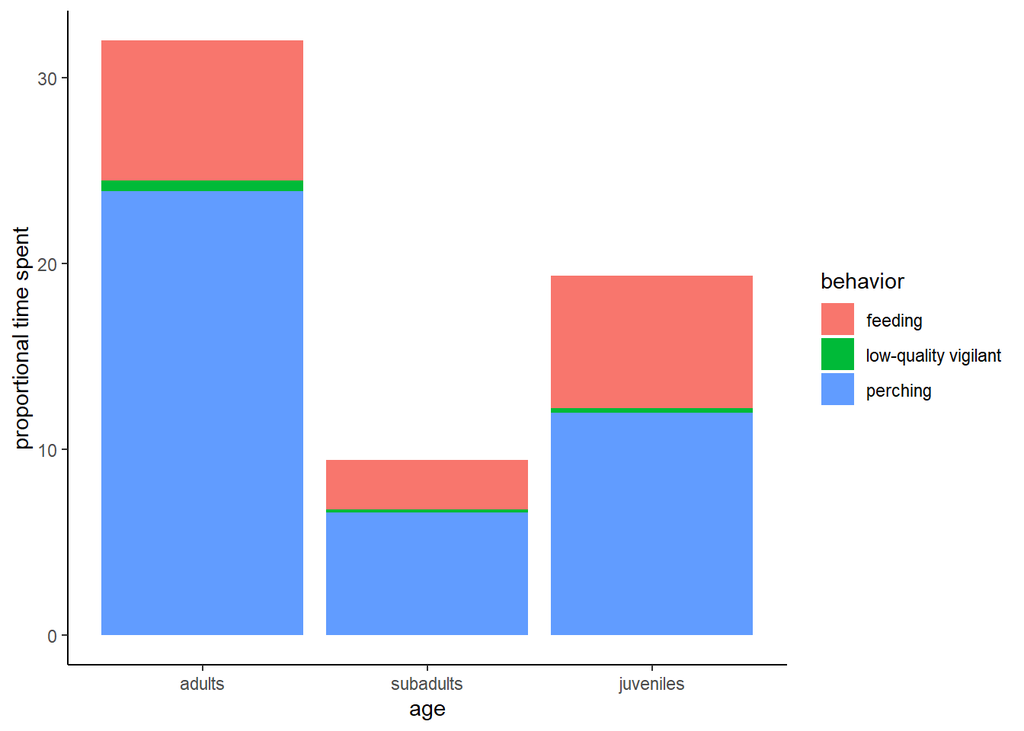

```r
# plot
a<-bind_rows(age.feed, age.perch, age.vig)
a$age<-factor(a$age, levels=c(1, 2, 4),
              labels=c("adults", "subadults", "juveniles"))

ggplot(a, aes(x=age, y=prop, fill=behavior)) +
  geom_bar(stat = "identity")+
  theme_classic() +
  labs(x="age", y="proportional time spent")
```

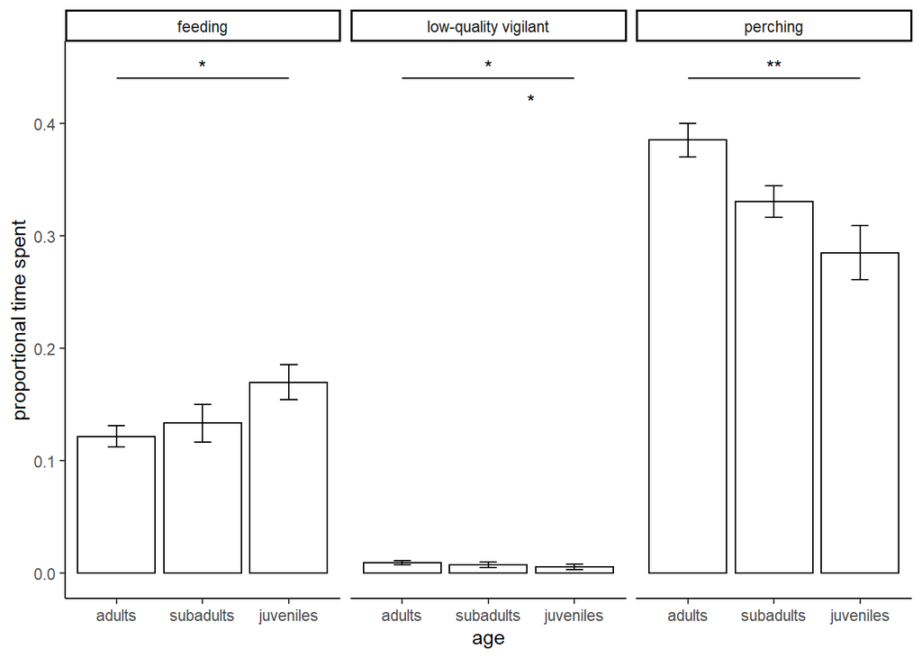

```r
b<-group_by(a, behavior, age) %>%
  summarise( mean=mean(prop), sd=sd(prop), n=n(), se=sd/sqrt(n))

f2<-ggplot(b, aes(x=age, y=mean)) +
  geom_bar(stat="identity", colour = "black", fill = "white") +
  theme_classic() +
  labs(x="age", y="proportional time spent") +
  facet_grid(.~behavior) +
  # theme(strip.background = element_rect(colour="black", fill="white",
  #                                     size=1.5, linetype="solid")) +
  geom_errorbar(aes(ymin=mean-se, ymax=mean+se), width=.2,
                                position=position_dodge(.9))
f2a<- f2 + geom_text(data=data.frame(x=c(2, 2,2.5, 2), y=c(0.45, 0.45, 0.42, 0.45),
                                    label = c("*", "*", "*" ,"**"),
                                    behavior=c("feeding","low-quality vigilant","low-quality vigilant", "perching")),
                    aes(x,y,label=label), inherit.aes=FALSE)

f2c<-f2a +   geom_segment(data = data.frame(x1=c(1,2,3), y=0.44,
                                            x2=c(2,3, 4),
                          behavior=c("feeding", "low-quality vigilant" ,"perching")),
                          aes(x = 1, xend = 3,
                              y = 0.44, yend = 0.44),
                          colour = "black")
f2c
```

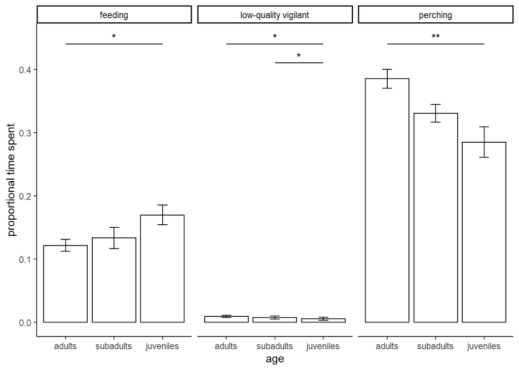

```r
f2d<-f2c +   geom_segment(data = data.frame(x1=2, y1=0.41,
                                            x2=3,
                                            behavior=c("low-quality vigilant")),
                          aes(x = x1, xend = x2,
                              y = y1, yend = y1),
                          colour = "black")
f2d
```

```r
ggsave("fig3.pdf", width = 174, height = 100, units = "mm")
```